# Analazing NOAAs Storm Database

Adolfo Zignago

1/29/2018

# Analazing NOAAs Storm DataBase: Impact in public health and economics problems

# ========================================

## Synopsis

Storms and other severe weather events can cause both public health and economic problems for communities and municipalities.

The basic goal of this analysis is to explore the NOAA Storm Database and answer some basic questions about severe weather events.

1. Across the United States, which types of events (as indicated in the variable) are most harmful with respect to population health?
2. Across the United States, which types of events have the greatest economic consequences?

### Data Processing

1. Download file

```r
fileURL = "https://d396qusza40orc.cloudfront.net/repdata%2Fdata%2FStormData.csv.bz2"
fileDest = "StormData.csv.bz2"
if(!file.exists(fileDest)) {
        download.file(fileURL, fileDest, method = "curl", mode = "wb")
}
```

2. Uncompress and load the file

```r
dataFile <- bzfile(fileDest)
stormData <- read.csv(dataFile, stringsAsFactors=F)
```

3. Check and verify the data

```r
dim(stormData)
```

```
## [1] 902297     37
```

```r
str(stormData)
```

```
## 'data.frame':    902297 obs. of  37 variables:
##  $ STATE__   : num  1 1 1 1 1 1 1 1 1 1 ...
##  $ BGN_DATE  : chr  "4/18/1950 0:00:00" "4/18/1950 0:00:00" "2/20/1951 0:00:00" "6/8/1951 0:00:00" ...
##  $ BGN_TIME  : chr  "0130" "0145" "1600" "0900" ...
##  $ TIME_ZONE : chr  "CST" "CST" "CST" "CST" ...
##  $ COUNTY    : num  97 3 57 89 43 77 9 123 125 57 ...
##  $ COUNTYNAME: chr  "MOBILE" "BALDWIN" "FAYETTE" "MADISON" ...
##  $ STATE     : chr  "AL" "AL" "AL" "AL" ...
##  $ EVTYPE    : chr  "TORNADO" "TORNADO" "TORNADO" "TORNADO" ...
##  $ BGN_RANGE : num  0 0 0 0 0 0 0 0 0 0 ...
##  $ BGN_AZI   : chr  "" "" "" "" ...
##  $ BGN_LOCATI: chr  "" "" "" "" ...
##  $ END_DATE  : chr  "" "" "" "" ...
##  $ END_TIME  : chr  "" "" "" "" ...
##  $ COUNTY_END: num  0 0 0 0 0 0 0 0 0 0 ...
```

[output cut: 23 more lines]

```r
colnames(stormData)
```

```
##  [1] "STATE__"    "BGN_DATE"   "BGN_TIME"   "TIME_ZONE"  "COUNTY"
##  [6] "COUNTYNAME" "STATE"      "EVTYPE"     "BGN_RANGE"  "BGN_AZI"
## [11] "BGN_LOCATI" "END_DATE"   "END_TIME"   "COUNTY_END" "COUNTYENDN"
## [16] "END_RANGE"  "END_AZI"    "END_LOCATI" "LENGTH"     "WIDTH"
## [21] "F"          "MAG"        "FATALITIES" "INJURIES"   "PROPDMG"
## [26] "PROPDMGEXP" "CROPDMG"    "CROPDMGEXP" "WFO"        "STATEOFFIC"
## [31] "ZONENAMES"  "LATITUDE"   "LONGITUDE"  "LATITUDE_E" "LONGITUDE_"
## [36] "REMARKS"    "REFNUM"
```

```r
head(stormData)
tail(stormData)
summary(stormData)
```

### Question 1: Across the United States, which types of events (as indicated in the variable) are most harmful with respect to population health?

### Data Analysis

```r
library(ggplot2)
stormDataDS <- stormData[, c("EVTYPE","FATALITIES","INJURIES")]
stormDataPH <- aggregate(stormDataDS[, c("FATALITIES", "INJURIES")], by=list(stormDataDS$EVTYPE), FUN = sum, na.rm = T)
colnames(stormDataPH)[1] <- c("EVTYPE")

stormDataPHbyFatalities <- stormDataPH[order(-stormDataPH[, "FATALITIES"]), ][1:10, ]
stormDataPHbyInjuries <- stormDataPH[order(-stormDataPH[, "INJURIES"]), ][1:10, ]
```

- The TORNADO is the most event with 5633 fatalities

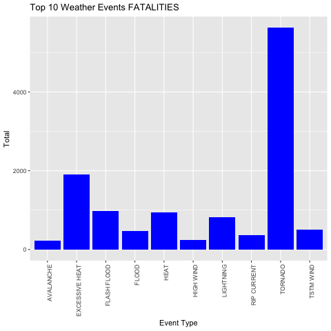

```r
fatalities <- ("./images/fatalities.png")
png(fatalities, height = 480, width = 480)
ggplot(stormDataPHbyFatalities, aes(x = EVTYPE, y = FATALITIES)) +
    geom_bar(stat = "identity", fill = "blue") +
    theme(axis.text.x = element_text(angle = 90, hjust = 1)) +
    xlab("Event Type") + ylab("Total") + ggtitle("Top 10 Weather Events FATALITIES")
dev.off()
```

- The TORNADO is the most event with 91346 injuries

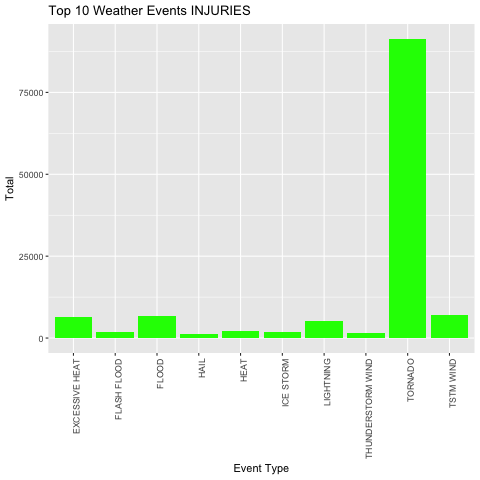

```r
injuries <- ("./images/injuries.png")
png(injuries, height = 480, width = 480)
ggplot(stormDataPHbyInjuries, aes(x = EVTYPE, y = INJURIES)) +
    geom_bar(stat = "identity", fill = "green") +
    theme(axis.text.x = element_text(angle = 90, hjust = 1)) +
    xlab("Event Type") + ylab("Total") + ggtitle("Top 10 Weather Events INJURIES")
dev.off()
```

```r
stormDataPHTotal <- with(stormDataDS, (aggregate(FATALITIES + INJURIES ~ EVTYPE, data = stormDataDS, FUN=sum, na.rm=T)))
colnames(stormDataPHTotal) <- c("EVTYPE", "TOTAL")
stormDataPHFI <- stormDataPHTotal[order(-stormDataPHTotal[, "TOTAL"]), ][1:10, ]

plot1 <- ("./images/plot1.png")
png(plot1, height = 480, width = 480)
ggplot(stormDataPHFI, aes(x = EVTYPE, y = TOTAL)) +
    geom_bar(stat = "identity", fill = "red") +
    theme(axis.text.x = element_text(angle = 90, hjust = 1)) +
    xlab("Event Type") + ylab("Total") + ggtitle("Top 10 Weather Events (FATALITIES + INJURIES)")
dev.off()
```

### Results

- The TORNADO is the most event with 96979 fatalities + injuries

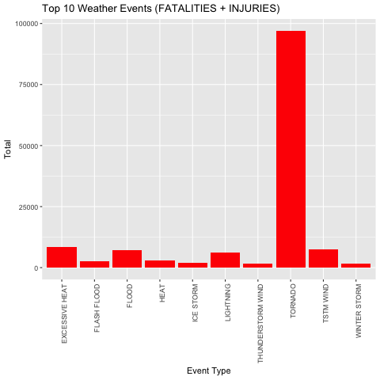

### Data Analysis

```r
stormDataDS <- stormData[,c("EVTYPE", "PROPDMG", "PROPDMGEXP", "CROPDMG", "CROPDMGEXP")]
#Calculate the values for Property Damages
stormDataDS$PROPDMGNUM = 0
stormDataDS[stormDataDS$PROPDMGEXP == "H", ]$PROPDMGNUM = stormDataDS[stormDataDS$PROPDMGEXP == "H", ]$PROPDMG * 10^2
stormDataDS[stormDataDS$PROPDMGEXP == "K", ]$PROPDMGNUM = stormDataDS[stormDataDS$PROPDMGEXP == "K", ]$PROPDMG * 10^3
stormDataDS[stormDataDS$PROPDMGEXP == "M", ]$PROPDMGNUM = stormDataDS[stormDataDS$PROPDMGEXP == "M", ]$PROPDMG * 10^6
stormDataDS[stormDataDS$PROPDMGEXP == "B", ]$PROPDMGNUM = stormDataDS[stormDataDS$PROPDMGEXP == "B", ]$PROPDMG * 10^9


# Calculate values for Crop Damage
stormDataDS$CROPDMGNUM = 0
stormDataDS[stormDataDS$CROPDMGEXP == "H", ]$CROPDMGNUM = stormDataDS[stormDataDS$CROPDMGEXP == "H", ]$CROPDMG * 10^2
stormDataDS[stormDataDS$CROPDMGEXP == "K", ]$CROPDMGNUM = stormDataDS[stormDataDS$CROPDMGEXP == "K", ]$CROPDMG * 10^3
stormDataDS[stormDataDS$CROPDMGEXP == "M", ]$CROPDMGNUM = stormDataDS[stormDataDS$CROPDMGEXP == "M", ]$CROPDMG * 10^6
stormDataDS[stormDataDS$CROPDMGEXP == "B", ]$CROPDMGNUM = stormDataDS[stormDataDS$CROPDMGEXP == "B", ]$CROPDMG * 10^9


# Aggregate the sum of both Property and Crop Damage
stormDataETotal <- with(stormDataDS, (aggregate(PROPDMGNUM + CROPDMGNUM ~ EVTYPE, data = stormDataDS, FUN=sum, na.rm=T)))
colnames(stormDataETotal) <- c("EVTYPE", "TOTAL")

stormDataEPC <- stormDataETotal[order(-stormDataETotal[, "TOTAL"]), ][1:10, ]
```

```r
plot2 <- ("./images/plot2.png")
png(plot2, height = 480, width = 480)
ggplot(stormDataEPC, aes(x = EVTYPE, y = (TOTAL)/10^9)) +
    geom_bar(stat = "identity", fill = "red") +
    theme(axis.text.x = element_text(angle = 90, hjust = 1)) +
    xlab("Event Type") + ylab("Total Damage US$ Billion") + ggtitle("Top 10 Weather Events (PROPERTY AND CROP Damage)")
dev.off()
```

### Results

- The FLOOD is the most event with 150.32 US$ Billion in Property and Crop damage

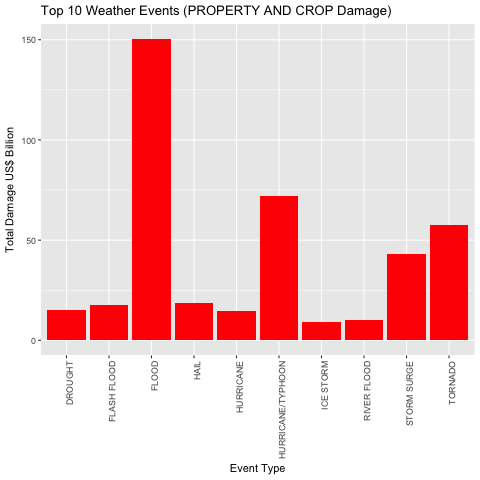